# Homework 01

```r
library(tidyverse)
library(GGally)
```

## Exercise 1

Check visually the file for presence of missing values. Use read_delim command (indicating the symbol for missing values if needed) to read in the data set Carseats_mod2.csv into a variable Carseats (the command should be included in your solution).

```r
Carseats <- read_delim("Carseats_mod2.csv", delim = ";", na = ".", skip = 3)
```

```r
Carseats
```

| Sales | CompPrice | Income | Advertising | Population | Price | ShelveLoc | Age | Education | Urban | US |
| --- | --- | --- | --- | --- | --- | --- | --- | --- | --- | --- |
| 9.50 | 138 | 73 | 11 | 276 | 120 | Bad | 42 | 17 | Yes | Yes |
| 11.22 | 111 | 48 | 16 | 260 | 83 | Good | 65 | 10 | Yes | Yes |
| 10.06 | 113 | 35 | 10 | 269 | 80 | NA | 69 | 12 | Yes | Yes |
| 7.40 | 117 | 100 | 4 | 466 | 97 | Medium | 55 | 14 | Yes | Yes |
| 4.15 | 141 | 64 | 3 | 340 | 128 | Bad | 38 | 13 | Yes | No |
| 10.81 | 124 | 113 | 13 | 501 | 72 | Bad | 78 | 16 | No | Yes |
| 6.63 | 115 | 105 | 0 | 45 | 108 | Medium | 71 | 15 | Yes | No |
| 11.85 | NA | 81 | 15 | 425 | 120 | Good | 67 | 10 | Yes | Yes |
| 6.54 | 132 | 110 | 0 | 108 | 124 | Medium | 76 | 10 | No | No |
| 4.69 | 132 | 113 | 0 | 131 | 124 | Medium | 76 | 17 | No | Yes |

[output cut: 390 more lines]

- Make sure that all variables that, according to description, should be numeric are numeric after reading data in.

```r
Carseats <- Carseats |>
  mutate(Sales = as.numeric(Sales),
         CompPrice = as.numeric(CompPrice),
         Income = as.numeric(Income),
         Advertising = as.numeric(Advertising),
         Population = as.numeric(Population),
         Price = as.numeric(Price),
         Age = as.numeric(Age),
         Education = as.numeric(Education))
```

```r
Carseats
```

| Sales | CompPrice | Income | Advertising | Population | Price | ShelveLoc | Age | Education | Urban | US |
| --- | --- | --- | --- | --- | --- | --- | --- | --- | --- | --- |
| 9.50 | 138 | 73 | 11 | 276 | 120 | Bad | 42 | 17 | Yes | Yes |
| 11.22 | 111 | 48 | 16 | 260 | 83 | Good | 65 | 10 | Yes | Yes |
| 10.06 | 113 | 35 | 10 | 269 | 80 | NA | 69 | 12 | Yes | Yes |
| 7.40 | 117 | 100 | 4 | 466 | 97 | Medium | 55 | 14 | Yes | Yes |
| 4.15 | 141 | 64 | 3 | 340 | 128 | Bad | 38 | 13 | Yes | No |
| 10.81 | 124 | 113 | 13 | 501 | 72 | Bad | 78 | 16 | No | Yes |
| 6.63 | 115 | 105 | 0 | 45 | 108 | Medium | 71 | 15 | Yes | No |
| 11.85 | NA | 81 | 15 | 425 | 120 | Good | 67 | 10 | Yes | Yes |
| 6.54 | 132 | 110 | 0 | 108 | 124 | Medium | 76 | 10 | No | No |
| 4.69 | 132 | 113 | 0 | 131 | 124 | Medium | 76 | 17 | No | Yes |

[output cut: 390 more lines]

## Exercise 2

Use summary() function to look at summary information about variables so that you see also list of values of character columns.

```r
summary(Carseats|>mutate(across(where(is.character),factor)))
```

```
     Sales          CompPrice         Income        Advertising       Population        Price        ShelveLoc        Age
 Min.   : 0.000   Min.   : 77.0   Min.   : 21.00   Min.   : 0.000   Min.   : 10.0   Min.   : 24.0   bad   :  1   Min.   : 25.0
 1st Qu.: 5.390   1st Qu.:115.0   1st Qu.: 42.50   1st Qu.: 0.000   1st Qu.:139.0   1st Qu.:100.0   Bad   : 95   1st Qu.: 40.0
 Median : 7.490   Median :124.5   Median : 69.00   Median : 5.000   Median :272.0   Median :117.5   Good  : 85   Median : 55.0
 Mean   : 7.496   Mean   :124.9   Mean   : 68.63   Mean   : 6.635   Mean   :264.8   Mean   :115.9   Medium:218   Mean   : 53.6
 3rd Qu.: 9.320   3rd Qu.:135.0   3rd Qu.: 91.00   3rd Qu.:12.000   3rd Qu.:398.5   3rd Qu.:131.0   NA's  :  1   3rd Qu.: 66.0
 Max.   :16.270   Max.   :175.0   Max.   :120.00   Max.   :29.000   Max.   :509.0   Max.   :191.0                Max.   :126.0
                  NA's   :2       NA's   :1                                         NA's   :2
   Education    Urban       US
 Min.   :10.0   No :118   No :142
 1st Qu.:12.0   Yes:282   Yes:258
 Median :14.0
 Mean   :13.9
 3rd Qu.:16.0
 Max.   :18.0
```

- Do you see anything which may indicate data errors? What? How many missing values are in the data set? (Hint - summary function works well with factor variables)

ShelveLoc variable has categories `Bad`, `Good`, and `Medium`. However, there is an entry labeled lowercase “bad”, which is likely a data entry error. This should be corrected as it represents the same category as `Bad`.

Age Max. value is 126.0 highly unlikely.

Missing Values:

- ShelveLoc variable has 1 missing value.
- CompPrice variable has 2 missing values.
- Income variable has 1 missing value.
- Price variable has 2 missing values.

Total 6 missing values across 4 columns.

## Exercise 3

Use na.omit() command to define a new data set Carseats2 where rows with missing values in the original data are left out

```r
Carseats2 <- na.omit(Carseats)
```

```r
summary(Carseats2|>mutate(across(where(is.character),factor)))
```

```
     Sales          CompPrice         Income        Advertising     Population        Price        ShelveLoc        Age
 Min.   : 0.000   Min.   : 77.0   Min.   : 21.00   Min.   : 0.0   Min.   : 10.0   Min.   : 24.0   bad   :  1   Min.   : 25.00
 1st Qu.: 5.360   1st Qu.:115.0   1st Qu.: 43.50   1st Qu.: 0.0   1st Qu.:138.0   1st Qu.:100.5   Bad   : 93   1st Qu.: 39.50
 Median : 7.490   Median :125.0   Median : 69.00   Median : 5.0   Median :272.0   Median :118.0   Good  : 83   Median : 55.00
 Mean   : 7.469   Mean   :125.1   Mean   : 68.72   Mean   : 6.6   Mean   :264.8   Mean   :116.0   Medium:218   Mean   : 53.48
 3rd Qu.: 9.315   3rd Qu.:135.0   3rd Qu.: 91.00   3rd Qu.:12.0   3rd Qu.:399.0   3rd Qu.:131.0                3rd Qu.: 66.00
 Max.   :16.270   Max.   :175.0   Max.   :120.00   Max.   :29.0   Max.   :509.0   Max.   :191.0                Max.   :126.00
   Education     Urban       US
 Min.   :10.00   No :117   No :141
 1st Qu.:12.00   Yes:278   Yes:254
 Median :14.00
 Mean   :13.92
 3rd Qu.:16.00
 Max.   :18.00
```

## Exercise 4

Use select() command to select columns from Sales to Advertising and from Price to Age from Carseats2 and apply ggpairs() function to the the result.

```r
selected_data <- Carseats2 |> select(Sales:Advertising, Price:Age)
```

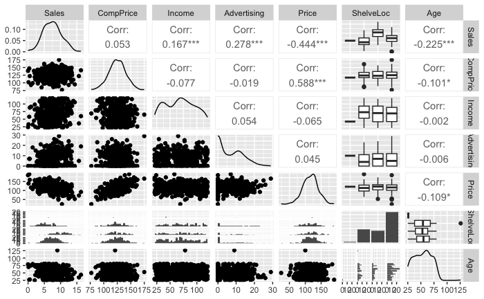

```r
ggpairs(selected_data, progress=FALSE)
```

- Are any possible data errors visible from the output?

Column ShelveLoc has 4th level category “bad” which should be replaced with “Bad”.

## Exercise 5

Use mutate() command with if_else() to correct data error in one of the factor variables, store the corrected data with the same name Carseats2

```r
Carseats2 <- Carseats2 |> mutate(ShelveLoc = if_else(ShelveLoc == "bad", "Bad", ShelveLoc))
```

```r
summary(Carseats2|>mutate(across(where(is.character),factor)))
```

```
     Sales          CompPrice         Income        Advertising     Population        Price        ShelveLoc        Age
 Min.   : 0.000   Min.   : 77.0   Min.   : 21.00   Min.   : 0.0   Min.   : 10.0   Min.   : 24.0   Bad   : 94   Min.   : 25.00
 1st Qu.: 5.360   1st Qu.:115.0   1st Qu.: 43.50   1st Qu.: 0.0   1st Qu.:138.0   1st Qu.:100.5   Good  : 83   1st Qu.: 39.50
 Median : 7.490   Median :125.0   Median : 69.00   Median : 5.0   Median :272.0   Median :118.0   Medium:218   Median : 55.00
 Mean   : 7.469   Mean   :125.1   Mean   : 68.72   Mean   : 6.6   Mean   :264.8   Mean   :116.0                Mean   : 53.48
 3rd Qu.: 9.315   3rd Qu.:135.0   3rd Qu.: 91.00   3rd Qu.:12.0   3rd Qu.:399.0   3rd Qu.:131.0                3rd Qu.: 66.00
 Max.   :16.270   Max.   :175.0   Max.   :120.00   Max.   :29.0   Max.   :509.0   Max.   :191.0                Max.   :126.00
   Education     Urban       US
 Min.   :10.00   No :117   No :141
 1st Qu.:12.00   Yes:278   Yes:254
 Median :14.00
 Mean   :13.92
 3rd Qu.:16.00
 Max.   :18.00
```

## Exercise 6

- Use summarize() command from dplyr package to compute a table with mean price for each combination of Urban and ShelveLoc

```r
mean_price_summary <- Carseats2 |>
  group_by(Urban, ShelveLoc) |>
  summarize(mean_price = mean(Price), .groups='drop')
```

| Urban | ShelveLoc | mean_price |
| --- | --- | --- |
| No | Bad | 109.8636 |
| No | Good | 117.4074 |
| No | Medium | 114.5882 |
| Yes | Bad | 116.0417 |
| Yes | Good | 118.7143 |
| Yes | Medium | 116.3733 |

## Exercise 7

Use ggplot() with geom_point to produce a scatter plot of Age (on x-axis) and Sales, color points according to ComPrice. Discuss the graph - is it sowing expected relationships between variables?

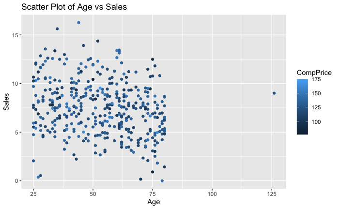

```r
ggplot(Carseats2, aes(x = Age, y = Sales, color = CompPrice)) +
  geom_point() +
  labs(title = "Scatter Plot of Age vs Sales",
       x = "Age",
       y = "Sales",
       color = "CompPrice")
```

Plot does not show any obvious relationships between Age and Sales or between Sales and CompPrice. We can observe an outlier with an age of more than 125, which might be an error in the data.